# Assignment1

RyanOConnor

9/24/2021

```
## [1] "PGE_2017_Q1_ElectricUsageByZip.csv"
## [1] "PGE_2018_Q1_ElectricUsageByZip.csv"
## [1] "PGE_2019_Q1_ElectricUsageByZip.csv"
## [1] "PGE_2020_Q1_ElectricUsageByZip.csv"
## [1] "PGE_2021_Q1_ElectricUsageByZip.csv"
## [1] "PGE_2017_Q2_ElectricUsageByZip.csv"
## [1] "PGE_2018_Q2_ElectricUsageByZip.csv"
## [1] "PGE_2019_Q2_ElectricUsageByZip.csv"
## [1] "PGE_2020_Q2_ElectricUsageByZip.csv"
## [1] "PGE_2021_Q2_ElectricUsageByZip.csv"
## [1] "PGE_2017_Q3_ElectricUsageByZip.csv"
## [1] "PGE_2018_Q3_ElectricUsageByZip.csv"
## [1] "PGE_2019_Q3_ElectricUsageByZip.csv"
## [1] "PGE_2020_Q3_ElectricUsageByZip.csv"
## [1] "PGE_2021_Q3_ElectricUsageByZip.csv"
```

```
## Error: 'PGE_2021_Q3_ElectricUsageByZip.csv' does not exist in current working directory ('/Users/ryanoconnor/Documents/GitHub/roconnor17.github.io').
```

The above error is expected and tolerated because of the lack of 2021_Q3 and 2021_Q4 CSVs. This error is remedied in the knitr process by annotating the beginning of the for loop chunks with {r, error = T} to instruct the knirt process to ignore the error.

```
## [1] "PGE_2017_Q1_GasUsageByZip.csv"
## [1] "PGE_2018_Q1_GasUsageByZip.csv"
## [1] "PGE_2019_Q1_GasUsageByZip.csv"
## [1] "PGE_2020_Q1_GasUsageByZip.csv"
## [1] "PGE_2021_Q1_GasUsageByZip.csv"
## [1] "PGE_2017_Q2_GasUsageByZip.csv"
## [1] "PGE_2018_Q2_GasUsageByZip.csv"
## [1] "PGE_2019_Q2_GasUsageByZip.csv"
## [1] "PGE_2020_Q2_GasUsageByZip.csv"
## [1] "PGE_2021_Q2_GasUsageByZip.csv"
## [1] "PGE_2017_Q3_GasUsageByZip.csv"
## [1] "PGE_2018_Q3_GasUsageByZip.csv"
## [1] "PGE_2019_Q3_GasUsageByZip.csv"
## [1] "PGE_2020_Q3_GasUsageByZip.csv"
## [1] "PGE_2021_Q3_GasUsageByZip.csv"
```

```
## Error: 'PGE_2021_Q3_GasUsageByZip.csv' does not exist in current working directory ('/Users/ryanoconnor/Documents/GitHub/roconnor17.github.io').
```

The above error is expected and tolerated because of the lack of 2021_Q3 and 2021_Q4 CSVs. This error is remedied in the knitr process by annotating the beginning of the for loop chunks with {r, error = T} to instruct the knirt process to ignore the error.

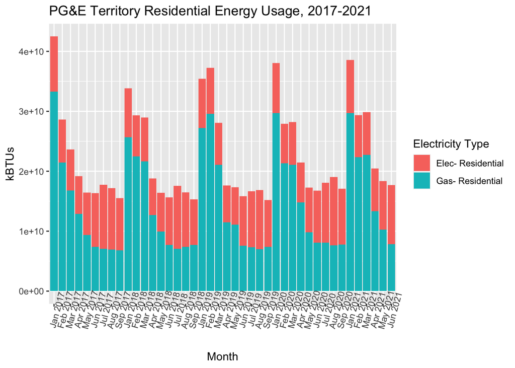

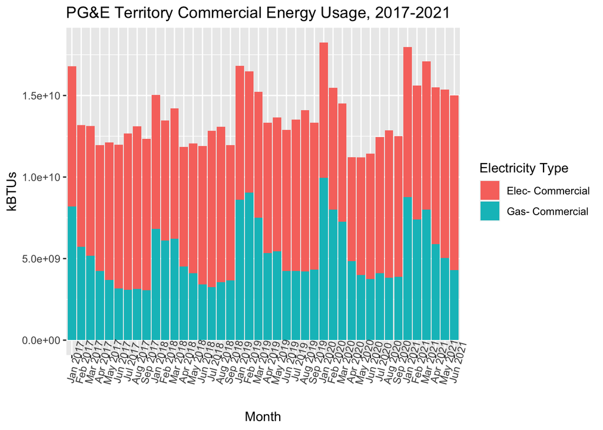

Comment on any observable changes in evergy consumption that may be attributable to the COVID-19 Pandemic:

When looking at the PG&E territorial residential energy use, there is very little appreciable difference between the Pre-Covid (2019) and COVID (2020-21) states in terms of gas energy consumpiton, and only a minor increase in home electricity useage during the Summer of 2020 as compared to the summer of 2019. However, there is a very noticable decline in the energy consumption in the commercial sector in the Spring and Summer of 2020 as compared to 2019, followed by an increase in the Spring and Summer of 2021 above even the “normal” pre-COVID levels of 2019 and prior.The decline in commercial energy consumption in 2020 is intuitively linked to the reduced commercial mobility of society. However, the increase in 2021 is surprising, considering the lingering restrictions in the Bay Area due to COVID, as well as the increase above Pre-COVID levels. One potential explanation for this is a “catch-up,” with both consumers and businesses making up for lost time and seeking to engage in more social activity follow the COVID “burnout.” What is interesting and notable is that, while intutitvely the proportion of time spent at home increased in 2020, the gross demand of residential energy did not increase significantly, but largely remained the same. This seems to indicate that staying at home more does not necessarily equate to using more energy at home.